# Summary of JAGS model

## Posterior Summary

|  | Lower95 | Median | Upper95 | Mean | SD | Mode | MCerr | MC%ofSD | SSeff | AC.50000 | psrf |
| --- | --- | --- | --- | --- | --- | --- | --- | --- | --- | --- | --- |
| **deviance** | 44515 | 44564 | 44618 | 44565 | 26.79 | 44565 | 0.3635 | 1.4 | 5430 | -0.02047 | 0.9987 |
| **sire.vcov[1,1]** | 0.00278 | 3.114 | 8.862 | 3.704 | 2.707 | 2.227 | 0.03706 | 1.4 | 5333 | -0.01603 | 1.003 |
| **sire.vcov[2,1]** | -6.018 | 0.6466 | 8.804 | 0.9453 | 3.791 | 0.3486 | 0.05187 | 1.4 | 5342 | 0.003122 | 0.9999 |
| **sire.vcov[3,1]** | -0.2275 | 0.3912 | 1.45 | 0.4704 | 0.4495 | 0.2814 | 0.00643 | 1.4 | 4886 | -0.0005968 | 1.002 |
| **sire.vcov[4,1]** | -1.006 | -0.05132 | 0.6992 | -0.06666 | 0.4187 | -0.03458 | 0.005687 | 1.4 | 5420 | -0.008097 | 1.001 |
| **sire.vcov[1,2]** | -6.018 | 0.6466 | 8.804 | 0.9453 | 3.791 | 0.3486 | 0.05187 | 1.4 | 5342 | 0.003122 | 0.9999 |
| **sire.vcov[2,2]** | 1.168 | 26.25 | 61.59 | 29.23 | 17.1 | 22.33 | 0.2223 | 1.3 | 5916 | -0.007985 | 1.001 |
| **sire.vcov[3,2]** | -1.652 | 0.1778 | 2.374 | 0.2478 | 0.9883 | 0.1519 | 0.01388 | 1.4 | 5071 | -0.03359 | 0.9992 |
| **sire.vcov[4,2]** | -1.669 | 0.2962 | 2.488 | 0.3466 | 1.007 | 0.2786 | 0.013 | 1.3 | 5996 | -0.03063 | 0.9999 |
| **sire.vcov[1,3]** | -0.2275 | 0.3912 | 1.45 | 0.4704 | 0.4495 | 0.2814 | 0.00643 | 1.4 | 4886 | -0.0005968 | 1.002 |
| **sire.vcov[2,3]** | -1.652 | 0.1778 | 2.374 | 0.2478 | 0.9883 | 0.1519 | 0.01388 | 1.4 | 5071 | -0.03359 | 0.9992 |
| **sire.vcov[3,3]** | 0.0005672 | 0.2288 | 0.6529 | 0.2714 | 0.1997 | 0.1818 | 0.002867 | 1.4 | 4850 | -0.003235 | 1.001 |
| **sire.vcov[4,3]** | -0.1685 | 0.0166 | 0.2705 | 0.02328 | 0.1098 | 0.01361 | 0.00145 | 1.3 | 5734 | -0.00771 | 1.002 |
| **sire.vcov[1,4]** | -1.006 | -0.05132 | 0.6992 | -0.06666 | 0.4187 | -0.03458 | 0.005687 | 1.4 | 5420 | -0.008097 | 1.001 |
| **sire.vcov[2,4]** | -1.669 | 0.2962 | 2.488 | 0.3466 | 1.007 | 0.2786 | 0.013 | 1.3 | 5996 | -0.03063 | 0.9999 |
| **sire.vcov[3,4]** | -0.1685 | 0.0166 | 0.2705 | 0.02328 | 0.1098 | 0.01361 | 0.00145 | 1.3 | 5734 | -0.00771 | 1.002 |
| **sire.vcov[4,4]** | 0.0008348 | 0.2368 | 0.6869 | 0.2839 | 0.2136 | 0.1662 | 0.0028 | 1.3 | 5818 | 0.0001088 | 1.001 |
| **dam.vcov[1,1]** | 10.96 | 25.31 | 48.71 | 27.37 | 10.65 | 23.13 | 0.1458 | 1.4 | 5340 | -0.004516 | 1.001 |
| **dam.vcov[2,1]** | -7.055 | 23.92 | 62.25 | 25.97 | 18.39 | 19.96 | 0.2497 | 1.4 | 5422 | -0.03335 | 1.001 |
| **dam.vcov[3,1]** | -0.4041 | 1.455 | 4.08 | 1.595 | 1.155 | 1.283 | 0.01602 | 1.4 | 5203 | 0.005687 | 0.9995 |
| **dam.vcov[4,1]** | -1.311 | 0.5044 | 2.784 | 0.5561 | 1.026 | 0.5174 | 0.01429 | 1.4 | 5156 | -0.001844 | 1.001 |
| **dam.vcov[1,2]** | -7.055 | 23.92 | 62.25 | 25.97 | 18.39 | 19.96 | 0.2497 | 1.4 | 5422 | -0.03335 | 1.001 |
| **dam.vcov[2,2]** | 79.29 | 176.2 | 322.4 | 190 | 68.44 | 157.3 | 0.8937 | 1.3 | 5864 | -0.01707 | 0.9998 |
| **dam.vcov[3,2]** | -1.084 | 3.994 | 10.8 | 4.327 | 2.988 | 3.555 | 0.03815 | 1.3 | 6136 | -0.01549 | 1.001 |
| **dam.vcov[4,2]** | -7.566 | -2.153 | 2.388 | -2.373 | 2.511 | -1.837 | 0.03557 | 1.4 | 4984 | 0.02445 | 1 |
| **dam.vcov[1,3]** | -0.4041 | 1.455 | 4.08 | 1.595 | 1.155 | 1.283 | 0.01602 | 1.4 | 5203 | 0.005687 | 0.9995 |
| **dam.vcov[2,3]** | -1.084 | 3.994 | 10.8 | 4.327 | 2.988 | 3.555 | 0.03815 | 1.3 | 6136 | -0.01549 | 1.001 |
| **dam.vcov[3,3]** | 0.08712 | 0.5159 | 1.17 | 0.5698 | 0.3096 | 0.4414 | 0.004411 | 1.4 | 4927 | -0.005215 | 1.001 |
| **dam.vcov[4,3]** | -0.5143 | -0.1631 | 0.1269 | -0.1784 | 0.1631 | -0.1494 | 0.002268 | 1.4 | 5175 | -0.01106 | 0.9998 |
| **dam.vcov[1,4]** | -1.311 | 0.5044 | 2.784 | 0.5561 | 1.026 | 0.5174 | 0.01429 | 1.4 | 5156 | -0.001844 | 1.001 |

[output cut: 97 more lines]

## V<sub>A</sub>

Latent scale

| metric | lower.hdi | median | mode | upper.hdi | pr.lt.hdi | pr.gt.hdi | 5pc.exceeds | pct.gt.0 |
| --- | --- | --- | --- | --- | --- | --- | --- | --- |
| Var(Trunk) | 0.01112 | 12.46 | 8.8 | 35.45 | 0 | 0.0498 | 35.42 | 1 |
| Var(Tail) | 4.672 | 105 | 89.64 | 246.4 | 0.0024 | 0.0474 | 242.6 | 1 |
| Var(Hatch) | 0.002269 | 0.9152 | 0.7289 | 2.611 | 0.0002 | 0.0496 | 2.605 | 1 |
| Var(Settle\|Hatch) | 0.003339 | 0.9473 | 0.6615 | 2.748 | 0 | 0.0498 | 2.745 | 1 |
| Cov(Trunk, Tail) | -24.07 | 2.587 | 1.432 | 35.22 | 0.0222 | 0.0276 | 29.5 | 0.5824 |
| Cov(Trunk, Hatch) | -0.9098 | 1.565 | 1.135 | 5.799 | 0.0168 | 0.033 | 5.144 | 0.9058 |
| Cov(Trunk, Settle\|Hatch) | -4.026 | -0.2053 | -0.1408 | 2.797 | 0.0192 | 0.0306 | 2.356 | 0.4286 |
| Cov(Tail, Hatch) | -6.607 | 0.711 | 0.7027 | 9.497 | 0.0244 | 0.0254 | 7.694 | 0.5974 |
| Cov(Tail, Settle\|Hatch) | -6.677 | 1.185 | 1.126 | 9.954 | 0.0216 | 0.0282 | 8.29 | 0.6504 |
| Cov(Hatch, Settle\|Hatch) | -0.674 | 0.0664 | 0.05916 | 1.082 | 0.0276 | 0.0222 | 0.8111 | 0.5886 |

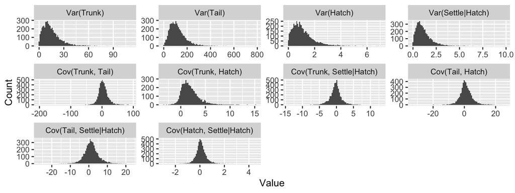

## V<sub>M</sub>

Latent scale

| metric | lower.hdi | median | mode | upper.hdi | pr.lt.hdi | pr.gt.hdi | 5pc.exceeds | pct.gt.0 |
| --- | --- | --- | --- | --- | --- | --- | --- | --- |
| Var(Trunk) | 6.098 | 21.86 | 20.72 | 46.05 | 0.0106 | 0.0392 | 43.73 | 0.9988 |
| Var(Tail) | 50.1 | 147.5 | 128.6 | 307.6 | 0.0136 | 0.0362 | 291.1 | 0.9998 |
| Var(Hatch) | -0.4407 | 0.2742 | 0.264 | 1.029 | 0.0154 | 0.0344 | 0.9048 | 0.8356 |
| Var(Settle\|Hatch) | -0.4791 | 0.1072 | 0.09062 | 0.8002 | 0.0266 | 0.0232 | 0.6339 | 0.6758 |
| Cov(Trunk, Tail) | -6.742 | 22.96 | 19.27 | 64.82 | 0.0196 | 0.0302 | 58.26 | 0.9416 |
| Cov(Trunk, Hatch) | -1.172 | 1.009 | 0.749 | 3.621 | 0.017 | 0.0328 | 3.257 | 0.8542 |
| Cov(Trunk, Settle\|Hatch) | -1.475 | 0.5749 | 0.4999 | 2.928 | 0.0282 | 0.0216 | 2.483 | 0.7304 |
| Cov(Tail, Hatch) | -1.451 | 3.775 | 3.48 | 10.93 | 0.023 | 0.0268 | 9.636 | 0.9306 |
| Cov(Tail, Settle\|Hatch) | -8.306 | -2.491 | -2.103 | 2.205 | 0.0288 | 0.021 | 1.14 | 0.1268 |
| Cov(Hatch, Settle\|Hatch) | -0.6048 | -0.1905 | -0.178 | 0.1496 | 0.0272 | 0.0226 | 0.08191 | 0.1178 |

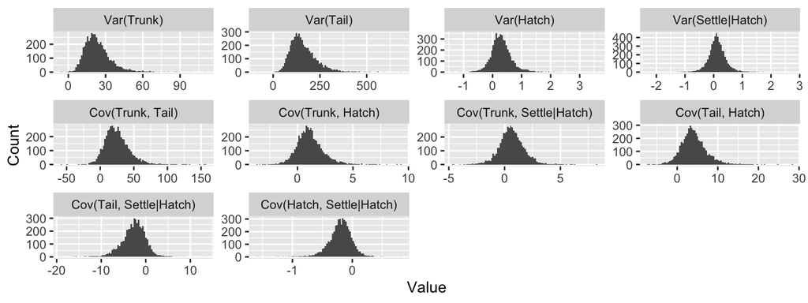

## V<sub>D</sub>

Latent scale

| metric | lower.hdi | median | mode | upper.hdi | pr.lt.hdi | pr.gt.hdi | 5pc.exceeds | pct.gt.0 |
| --- | --- | --- | --- | --- | --- | --- | --- | --- |
| Var(Trunk) | 0.003119 | 9.227 | 5.384 | 26.39 | 0 | 0.0498 | 26.36 | 1 |
| Var(Tail) | 0.0003354 | 71.46 | 61.78 | 168.4 | 0 | 0.0498 | 168.3 | 1 |
| Var(Hatch) | 0.03863 | 0.99 | 0.8764 | 2.217 | 0.0022 | 0.0476 | 2.201 | 1 |
| Var(Settle\|Hatch) | 0.5405 | 1.34 | 1.238 | 2.52 | 0.0084 | 0.0414 | 2.465 | 1 |
| Cov(Trunk, Tail) | -13.58 | 5.859 | 3.774 | 31.53 | 0.01 | 0.0398 | 29.28 | 0.7598 |
| Cov(Trunk, Hatch) | -3.083 | -0.4309 | -0.474 | 2.142 | 0.0224 | 0.0274 | 1.677 | 0.3298 |
| Cov(Trunk, Settle\|Hatch) | -3.201 | -0.4134 | -0.363 | 2.052 | 0.025 | 0.0248 | 1.509 | 0.3468 |
| Cov(Tail, Hatch) | -4.67 | 1.355 | 1.161 | 7.843 | 0.018 | 0.0318 | 6.967 | 0.7014 |
| Cov(Tail, Settle\|Hatch) | -7.22 | -1.036 | -1.044 | 4.504 | 0.021 | 0.0288 | 3.747 | 0.3418 |
| Cov(Hatch, Settle\|Hatch) | -0.4634 | 0.2205 | 0.2464 | 0.9083 | 0.0264 | 0.0234 | 0.7778 | 0.7568 |

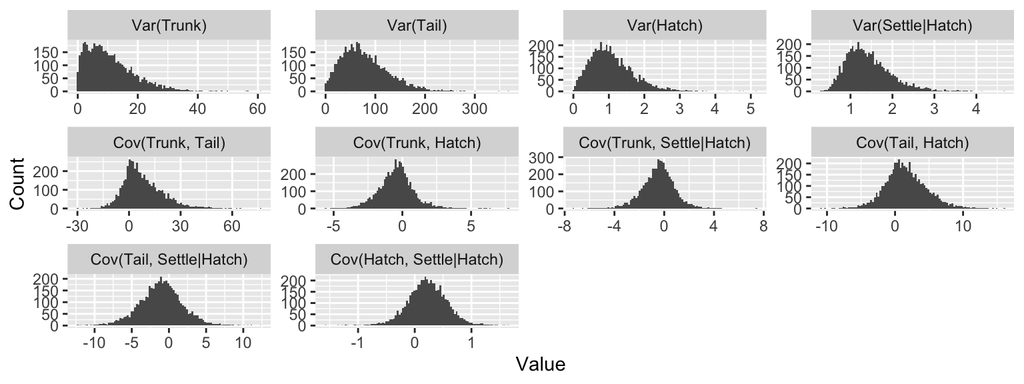

## V<sub>R</sub>

Latent scale

| metric | lower.hdi | median | mode | upper.hdi | pr.lt.hdi | pr.gt.hdi | 5pc.exceeds | pct.gt.0 |
| --- | --- | --- | --- | --- | --- | --- | --- | --- |
| Var(Trunk) | 81.7 | 89.06 | 88.77 | 96.77 | 0.0232 | 0.0266 | 95.7 | 1 |
| Var(Tail) | 303 | 329.5 | 328.4 | 359.6 | 0.023 | 0.0268 | 355 | 1 |
| Var(Hatch) | 0 | 0 | 0 | 0 | 0 | 0 | 0 | 0 |
| Var(Settle\|Hatch) | 0 | 0 | 0 | 0 | 0 | 0 | 0 | 0 |
| Cov(Trunk, Tail) | 39.9 | 51.01 | 51.02 | 61.7 | 0.0194 | 0.0304 | 60.4 | 1 |
| Cov(Trunk, Hatch) | 0 | 0 | 0 | 0 | 0 | 0 | 0 | 0 |
| Cov(Trunk, Settle\|Hatch) | 0 | 0 | 0 | 0 | 0 | 0 | 0 | 0 |
| Cov(Tail, Hatch) | 0 | 0 | 0 | 0 | 0 | 0 | 0 | 0 |
| Cov(Tail, Settle\|Hatch) | 0 | 0 | 0 | 0 | 0 | 0 | 0 | 0 |
| Cov(Hatch, Settle\|Hatch) | 0 | 0 | 0 | 0 | 0 | 0 | 0 | 0 |

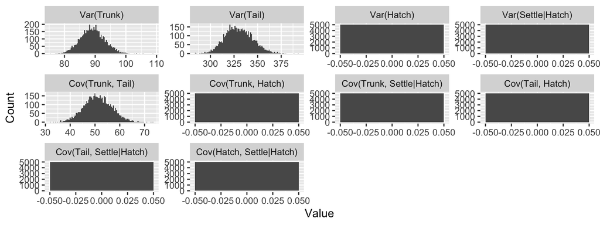

## V<sub>P</sub>

Latent scale

| metric | lower.hdi | median | mode | upper.hdi | pr.lt.hdi | pr.gt.hdi | 5pc.exceeds | pct.gt.0 |
| --- | --- | --- | --- | --- | --- | --- | --- | --- |
| Var(Trunk) | 103.9 | 121.2 | 118.7 | 146.8 | 0.0122 | 0.0376 | 144.3 | 1 |
| Var(Tail) | 451.2 | 557.9 | 542.9 | 711.8 | 0.0094 | 0.0404 | 699.9 | 1 |
| Var(Hatch) | 0.521 | 1.055 | 0.9704 | 1.877 | 0.0134 | 0.0364 | 1.787 | 1 |
| Var(Settle\|Hatch) | 0.5136 | 0.9842 | 0.9022 | 1.686 | 0.0066 | 0.0432 | 1.656 | 1 |
| Cov(Trunk, Tail) | 45.76 | 78.11 | 76.52 | 118.9 | 0.019 | 0.0308 | 112.9 | 1 |
| Cov(Trunk, Hatch) | -0.2915 | 1.812 | 1.593 | 4.5 | 0.0168 | 0.033 | 4.161 | 0.9638 |
| Cov(Trunk, Settle\|Hatch) | -1.821 | 0.3276 | 0.2473 | 2.605 | 0.0212 | 0.0286 | 2.234 | 0.6364 |
| Cov(Tail, Hatch) | -0.8918 | 4.668 | 4.262 | 11.38 | 0.0166 | 0.0332 | 10.62 | 0.965 |
| Cov(Tail, Settle\|Hatch) | -7.855 | -2.116 | -1.621 | 2.91 | 0.0302 | 0.0196 | 1.719 | 0.176 |
| Cov(Hatch, Settle\|Hatch) | -0.5434 | -0.0898 | -0.08268 | 0.2639 | 0.0226 | 0.0272 | 0.2012 | 0.3006 |

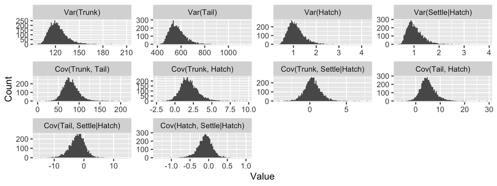

## V<sub>M</sub> / V<sub>A</sub>

Latent scale

| metric | lower.hdi | median | mode | upper.hdi | pr.lt.hdi | pr.gt.hdi | 5pc.exceeds | pct.gt.1 |
| --- | --- | --- | --- | --- | --- | --- | --- | --- |
| Var(Trunk) | -0.08367 | 1.854 | 1.146 | 12.89 | 0 | 0.0498 | 12.88 | 0.7504 |
| Var(Tail) | 0.06143 | 1.488 | 1.041 | 6.369 | 0.0014 | 0.0484 | 6.316 | 0.6878 |
| Var(Hatch) | -0.2439 | 0.3237 | 0.09698 | 3.455 | 0 | 0.0498 | 3.454 | 0.2076 |
| Var(Settle\|Hatch) | -0.2462 | 0.1267 | -0.02242 | 1.973 | 0 | 0.0498 | 1.965 | 0.1202 |
| Cov(Trunk, Tail) | -35.61 | 0.4098 | 0.1669 | 36.68 | 0.0284 | 0.0214 | 16.97 | 0.4096 |
| Cov(Trunk, Hatch) | -8.553 | 0.4569 | 0.3325 | 14.31 | 0.0306 | 0.0192 | 6.803 | 0.3178 |
| Cov(Trunk, Settle\|Hatch) | -11.55 | -0.3173 | -0.2942 | 13.19 | 0.0262 | 0.0236 | 5.85 | 0.178 |
| Cov(Tail, Hatch) | -25.7 | 0.2405 | 0.1714 | 22.67 | 0.0232 | 0.0266 | 12 | 0.351 |
| Cov(Tail, Settle\|Hatch) | -14 | -0.5155 | -0.5548 | 11.56 | 0.0232 | 0.0266 | 5.849 | 0.1734 |
| Cov(Hatch, Settle\|Hatch) | -9.496 | -0.3758 | -0.3863 | 10.37 | 0.0278 | 0.022 | 4.353 | 0.1616 |

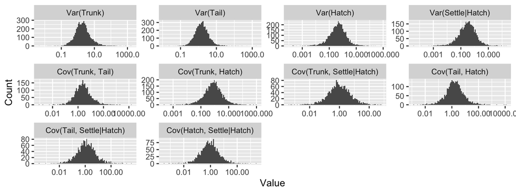

## V<sub>D</sub> / V<sub>A</sub>

Latent scale

| metric | lower.hdi | median | mode | upper.hdi | pr.lt.hdi | pr.gt.hdi | 5pc.exceeds | pct.gt.1 |
| --- | --- | --- | --- | --- | --- | --- | --- | --- |
| Var(Trunk) | 0.0002143 | 0.6947 | 0.3524 | 7.777 | 0 | 0.0498 | 7.776 | 0.3844 |
| Var(Tail) | 0.000002977 | 0.6523 | 0.4027 | 3.934 | 0 | 0.0498 | 3.911 | 0.3286 |
| Var(Hatch) | 0.001149 | 1.044 | 0.6239 | 10.66 | 0 | 0.0498 | 10.64 | 0.5152 |
| Var(Settle\|Hatch) | 0.112 | 1.391 | 0.9086 | 10.08 | 0 | 0.0498 | 10.07 | 0.6454 |
| Cov(Trunk, Tail) | -14.03 | 0.01263 | -0.06912 | 16.37 | 0.0292 | 0.0206 | 6.565 | 0.224 |
| Cov(Trunk, Hatch) | -7.927 | -0.2122 | -0.2691 | 8.263 | 0.024 | 0.0258 | 3.647 | 0.114 |
| Cov(Trunk, Settle\|Hatch) | -14.3 | -0.03291 | -0.07543 | 16.04 | 0.026 | 0.0238 | 7.121 | 0.228 |
| Cov(Tail, Hatch) | -14.11 | -0.009728 | -0.08445 | 16.55 | 0.0258 | 0.024 | 7.302 | 0.2292 |
| Cov(Tail, Settle\|Hatch) | -11.75 | -0.215 | -0.3098 | 11.85 | 0.0248 | 0.025 | 5.322 | 0.1824 |
| Cov(Hatch, Settle\|Hatch) | -19.19 | 0.03618 | -0.03753 | 15.92 | 0.0216 | 0.0282 | 8.935 | 0.2688 |

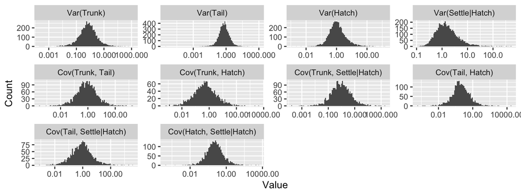

## Variance partitioning

Latent scale  
$(VA / VP) \times 100$

|  | Trunk | Tail |
| --- | --- | --- |
| **lower.hdi** | 0.009679 | 1.959 |
| **median** | 10.18 | 18.65 |
| **mode** | 7.914 | 16.18 |
| **upper.hdi** | 28.18 | 43.7 |
| **pr.lt.hdi** | 0 | 0.0094 |
| **pr.gt.hdi** | 0.0498 | 0.0404 |
| **5pc.exceeds** | 28.15 | 42.26 |

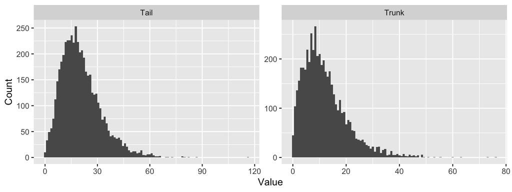

$(VM / VP) \times 100$

|  | Trunk | Tail |
| --- | --- | --- |
| **lower.hdi** | 5.978 | 11.11 |
| **median** | 18.15 | 26.79 |
| **mode** | 17.88 | 24.67 |
| **upper.hdi** | 32.54 | 44.72 |
| **pr.lt.hdi** | 0.0146 | 0.0194 |
| **pr.gt.hdi** | 0.0352 | 0.0304 |
| **5pc.exceeds** | 30.97 | 42.37 |

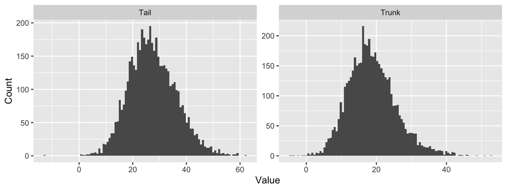

$(VD / VP) \times 100$

|  | Trunk | Tail |
| --- | --- | --- |
| **lower.hdi** | 0.002375 | 0.00005948 |
| **median** | 7.519 | 12.66 |
| **mode** | 4.245 | 10.88 |
| **upper.hdi** | 21.77 | 29.93 |
| **pr.lt.hdi** | 0 | 0 |
| **pr.gt.hdi** | 0.0498 | 0.0498 |
| **5pc.exceeds** | 21.77 | 29.92 |

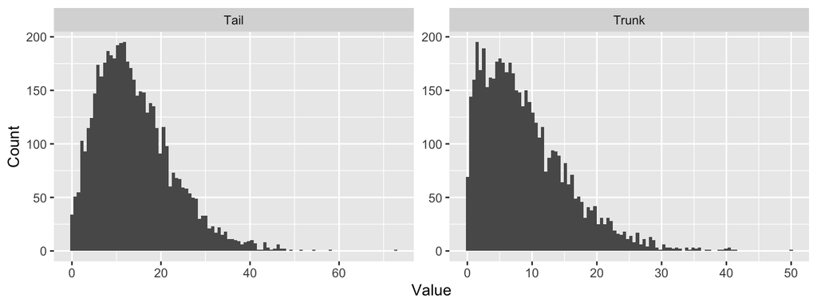

## Summarize QGmvparams posteriors

### Block means on expected data scale

Hatching actually measured in blocks 5, 7, 8, 9, 10, 11, 12, 13, 14, 16  
Settling actually measured in blocks 3, 4, 5, 7, 8, 9, 10, 11, 12, 14  
But **Block** has been re-coded for running model in runjags().

| Block | Stage | lower.hdi | median | mode | upper.hdi | pr.lt.hdi | pr.gt.hdi | 5pc.exceeds |
| --- | --- | --- | --- | --- | --- | --- | --- | --- |
| 3 | Hatch | NA | NA | NA | NA | NA | NA | NA |
| 4 | Hatch | NA | NA | NA | NA | NA | NA | NA |
| 5 | Hatch | 0.51 | 0.77 | 0.82 | 0.96 | 0.047 | 0.0028 | 0.93 |
| 7 | Hatch | 0.53 | 0.79 | 0.83 | 0.96 | 0.042 | 0.0076 | 0.93 |
| 8 | Hatch | 0.52 | 0.78 | 0.82 | 0.95 | 0.042 | 0.0078 | 0.92 |
| 9 | Hatch | 0.67 | 0.87 | 0.91 | 0.98 | 0.049 | 0.0004 | 0.96 |
| 10 | Hatch | 0.46 | 0.71 | 0.73 | 0.91 | 0.025 | 0.025 | 0.89 |
| 11 | Hatch | 0.47 | 0.72 | 0.75 | 0.92 | 0.028 | 0.022 | 0.9 |
| 12 | Hatch | 0.68 | 0.88 | 0.92 | 0.97 | 0.049 | 0.0012 | 0.96 |
| 13 | Hatch | 0.55 | 0.8 | 0.84 | 0.96 | 0.043 | 0.0066 | 0.93 |
| 14 | Hatch | 0.62 | 0.85 | 0.89 | 0.97 | 0.048 | 0.0018 | 0.95 |
| 16 | Hatch | 0.77 | 0.92 | 0.94 | 0.98 | 0.049 | 0.0004 | 0.97 |
| 3 | Settle\|Hatch | 0.5 | 0.82 | 0.89 | 0.97 | 0.049 | 0.0004 | 0.95 |
| 4 | Settle\|Hatch | 0.57 | 0.85 | 0.91 | 0.97 | 0.049 | 0.0008 | 0.96 |
| 5 | Settle\|Hatch | 0.4 | 0.74 | 0.82 | 0.96 | 0.046 | 0.0036 | 0.93 |
| 7 | Settle\|Hatch | 0.62 | 0.87 | 0.92 | 0.97 | 0.049 | 0.0008 | 0.96 |
| 8 | Settle\|Hatch | 0.46 | 0.76 | 0.83 | 0.97 | 0.049 | 0.0012 | 0.93 |
| 9 | Settle\|Hatch | 0.33 | 0.65 | 0.72 | 0.91 | 0.031 | 0.019 | 0.89 |
| 10 | Settle\|Hatch | 0.35 | 0.66 | 0.71 | 0.93 | 0.041 | 0.0092 | 0.9 |
| 11 | Settle\|Hatch | 0.33 | 0.65 | 0.74 | 0.92 | 0.033 | 0.016 | 0.88 |
| 12 | Settle\|Hatch | 0.33 | 0.65 | 0.71 | 0.91 | 0.03 | 0.02 | 0.89 |
| 13 | Settle\|Hatch | NA | NA | NA | NA | NA | NA | NA |
| 14 | Settle\|Hatch | 0.55 | 0.82 | 0.89 | 0.97 | 0.05 | 0.0002 | 0.95 |
| 16 | Settle\|Hatch | NA | NA | NA | NA | NA | NA | NA |

Summary across blocks

| Stage | min | max | mean_median | mean_mode |
| --- | --- | --- | --- | --- |
| Hatch | 0.71 | 0.92 | 0.81 | 0.85 |
| Settle\|Hatch | 0.65 | 0.87 | 0.75 | 0.81 |

### Block means on latent scale

| Block | Hatch | Settle\|Hatch |
| --- | --- | --- |
| 3 | NA | 1.8 |
| 4 | NA | 2.1 |
| 5 | 1.5 | 1.3 |
| 7 | 1.6 | 2.2 |
| 8 | 1.5 | 1.4 |
| 9 | 2.3 | 0.77 |
| 10 | 1.1 | 0.84 |
| 11 | 1.2 | 0.78 |
| 12 | 2.4 | 0.79 |
| 13 | 1.6 | NA |
| 14 | 2 | 1.8 |
| 16 | 2.8 | NA |

### VA for settling and hatching on data scale across blocks

| Block | Stage | lower.hdi | median | mode | upper.hdi | pr.lt.hdi | pr.gt.hdi | 5pc.exceeds | pct.gt.0 |
| --- | --- | --- | --- | --- | --- | --- | --- | --- | --- |
| 1 | Var(Hatch) | 0.0023 | 0.92 | 0.73 | 2.6 | 0.0002 | 0.05 | 2.6 | 1 |
| 2 | Var(Hatch) | 0.0023 | 0.92 | 0.73 | 2.6 | 0.0002 | 0.05 | 2.6 | 1 |
| 3 | Var(Hatch) | 0.0023 | 0.92 | 0.73 | 2.6 | 0.0002 | 0.05 | 2.6 | 1 |
| 4 | Var(Hatch) | 0.0023 | 0.92 | 0.73 | 2.6 | 0.0002 | 0.05 | 2.6 | 1 |
| 5 | Var(Hatch) | 0.000017 | 0.017 | 0.0086 | 0.069 | 0 | 0.05 | 0.069 | 1 |
| 7 | Var(Hatch) | 0.000025 | 0.016 | 0.0082 | 0.069 | 0 | 0.05 | 0.068 | 1 |
| 8 | Var(Hatch) | 0.000025 | 0.017 | 0.0087 | 0.069 | 0 | 0.05 | 0.069 | 1 |
| 9 | Var(Hatch) | 0.0000087 | 0.008 | 0.004 | 0.046 | 0 | 0.05 | 0.046 | 1 |
| 10 | Var(Hatch) | 0.000037 | 0.024 | 0.012 | 0.077 | 0 | 0.05 | 0.077 | 1 |
| 11 | Var(Hatch) | 0.000018 | 0.023 | 0.011 | 0.076 | 0 | 0.05 | 0.075 | 1 |
| 12 | Var(Hatch) | 0.0000045 | 0.0069 | 0.0034 | 0.044 | 0 | 0.05 | 0.044 | 1 |
| 13 | Var(Hatch) | 0.0000097 | 0.015 | 0.0076 | 0.064 | 0 | 0.05 | 0.064 | 1 |
| 14 | Var(Hatch) | 0.0000075 | 0.01 | 0.0052 | 0.053 | 0 | 0.05 | 0.053 | 1 |
| 15 | Var(Hatch) | 0.0023 | 0.92 | 0.73 | 2.6 | 0.0002 | 0.05 | 2.6 | 1 |
| 16 | Var(Hatch) | 0.0000034 | 0.0039 | 0.002 | 0.031 | 0 | 0.05 | 0.031 | 1 |
| 1 | Var(Settle\|Hatch) | 0.0033 | 0.95 | 0.66 | 2.7 | 0 | 0.05 | 2.7 | 1 |
| 2 | Var(Settle\|Hatch) | 0.0033 | 0.95 | 0.66 | 2.7 | 0 | 0.05 | 2.7 | 1 |
| 3 | Var(Settle\|Hatch) | 0.000027 | 0.014 | 0.0069 | 0.067 | 0.0002 | 0.05 | 0.067 | 1 |
| 4 | Var(Settle\|Hatch) | 0.0000036 | 0.0099 | 0.005 | 0.06 | 0 | 0.05 | 0.06 | 1 |
| 5 | Var(Settle\|Hatch) | 0.000015 | 0.021 | 0.01 | 0.079 | 0 | 0.05 | 0.079 | 1 |
| 7 | Var(Settle\|Hatch) | 0.0000024 | 0.0087 | 0.0044 | 0.055 | 0 | 0.05 | 0.055 | 1 |
| 8 | Var(Settle\|Hatch) | 0.0000051 | 0.019 | 0.0095 | 0.075 | 0 | 0.05 | 0.075 | 1 |
| 9 | Var(Settle\|Hatch) | 0.000041 | 0.027 | 0.015 | 0.086 | 0 | 0.05 | 0.086 | 1 |
| 10 | Var(Settle\|Hatch) | 0.000018 | 0.026 | 0.014 | 0.086 | 0 | 0.05 | 0.085 | 1 |
| 11 | Var(Settle\|Hatch) | 0.0000063 | 0.027 | 0.015 | 0.086 | 0 | 0.05 | 0.086 | 1 |
| 12 | Var(Settle\|Hatch) | 0.00011 | 0.027 | 0.014 | 0.087 | 0.0002 | 0.05 | 0.087 | 1 |
| 13 | Var(Settle\|Hatch) | 0.0033 | 0.95 | 0.66 | 2.7 | 0 | 0.05 | 2.7 | 1 |
| 14 | Var(Settle\|Hatch) | 0.0000056 | 0.013 | 0.0067 | 0.065 | 0 | 0.05 | 0.065 | 1 |
| 15 | Var(Settle\|Hatch) | 0.0033 | 0.95 | 0.66 | 2.7 | 0 | 0.05 | 2.7 | 1 |
| 16 | Var(Settle\|Hatch) | 0.0033 | 0.95 | 0.66 | 2.7 | 0 | 0.05 | 2.7 | 1 |

[output cut: 75 more lines]

### VP for settling and hatching on data scale across blocks

| Block | Stage | lower.hdi | median | mode | upper.hdi | pr.lt.hdi | pr.gt.hdi | 5pc.exceeds | pct.gt.0 |
| --- | --- | --- | --- | --- | --- | --- | --- | --- | --- |
| 1 | Var(Hatch) | 0.52 | 1.1 | 0.97 | 1.9 | 0.013 | 0.036 | 1.8 | 1 |
| 2 | Var(Hatch) | 0.52 | 1.1 | 0.97 | 1.9 | 0.013 | 0.036 | 1.8 | 1 |
| 3 | Var(Hatch) | 0.52 | 1.1 | 0.97 | 1.9 | 0.013 | 0.036 | 1.8 | 1 |
| 4 | Var(Hatch) | 0.52 | 1.1 | 0.97 | 1.9 | 0.013 | 0.036 | 1.8 | 1 |
| 5 | Var(Hatch) | 0.063 | 0.18 | 0.21 | 0.25 | 0.05 | 0 | 0.25 | 1 |
| 7 | Var(Hatch) | 0.066 | 0.17 | 0.21 | 0.25 | 0.05 | 0.0002 | 0.25 | 1 |
| 8 | Var(Hatch) | 0.071 | 0.17 | 0.21 | 0.25 | 0.05 | 0 | 0.25 | 1 |
| 9 | Var(Hatch) | 0.028 | 0.11 | 0.088 | 0.22 | 0.004 | 0.046 | 0.22 | 1 |
| 10 | Var(Hatch) | 0.096 | 0.21 | 0.23 | 0.25 | 0.05 | 0 | 0.25 | 1 |
| 11 | Var(Hatch) | 0.092 | 0.2 | 0.23 | 0.25 | 0.05 | 0 | 0.25 | 1 |
| 12 | Var(Hatch) | 0.027 | 0.1 | 0.072 | 0.22 | 0.0028 | 0.047 | 0.22 | 1 |
| 13 | Var(Hatch) | 0.064 | 0.16 | 0.21 | 0.25 | 0.05 | 0.0002 | 0.25 | 1 |
| 14 | Var(Hatch) | 0.048 | 0.13 | 0.11 | 0.25 | 0.05 | 0 | 0.23 | 1 |
| 15 | Var(Hatch) | 0.52 | 1.1 | 0.97 | 1.9 | 0.013 | 0.036 | 1.8 | 1 |
| 16 | Var(Hatch) | 0.023 | 0.075 | 0.053 | 0.18 | 0.0004 | 0.049 | 0.18 | 1 |
| 1 | Var(Settle\|Hatch) | 0.51 | 0.98 | 0.9 | 1.7 | 0.0066 | 0.043 | 1.7 | 1 |
| 2 | Var(Settle\|Hatch) | 0.51 | 0.98 | 0.9 | 1.7 | 0.0066 | 0.043 | 1.7 | 1 |
| 3 | Var(Settle\|Hatch) | 0.046 | 0.15 | 0.2 | 0.25 | 0.049 | 0.0008 | 0.25 | 1 |
| 4 | Var(Settle\|Hatch) | 0.038 | 0.12 | 0.082 | 0.25 | 0.049 | 0.0004 | 0.24 | 1 |
| 5 | Var(Settle\|Hatch) | 0.064 | 0.19 | 0.22 | 0.25 | 0.05 | 0 | 0.25 | 1 |
| 7 | Var(Settle\|Hatch) | 0.029 | 0.12 | 0.074 | 0.24 | 0.0076 | 0.042 | 0.24 | 1 |
| 8 | Var(Settle\|Hatch) | 0.062 | 0.18 | 0.22 | 0.25 | 0.05 | 0 | 0.25 | 1 |
| 9 | Var(Settle\|Hatch) | 0.1 | 0.22 | 0.24 | 0.25 | 0.05 | 0.0002 | 0.25 | 1 |
| 10 | Var(Settle\|Hatch) | 0.092 | 0.22 | 0.24 | 0.25 | 0.05 | 0 | 0.25 | 1 |
| 11 | Var(Settle\|Hatch) | 0.1 | 0.22 | 0.24 | 0.25 | 0.05 | 0.0002 | 0.25 | 1 |
| 12 | Var(Settle\|Hatch) | 0.1 | 0.22 | 0.24 | 0.25 | 0.05 | 0 | 0.25 | 1 |
| 13 | Var(Settle\|Hatch) | 0.51 | 0.98 | 0.9 | 1.7 | 0.0066 | 0.043 | 1.7 | 1 |
| 14 | Var(Settle\|Hatch) | 0.047 | 0.15 | 0.2 | 0.25 | 0.05 | 0.0002 | 0.25 | 1 |
| 15 | Var(Settle\|Hatch) | 0.51 | 0.98 | 0.9 | 1.7 | 0.0066 | 0.043 | 1.7 | 1 |
| 16 | Var(Settle\|Hatch) | 0.51 | 0.98 | 0.9 | 1.7 | 0.0066 | 0.043 | 1.7 | 1 |

[output cut: 75 more lines]

## Genetic selection gradients

$\boldsymbol{\beta}_{g} = \mathbf{G}^{-1}\mathbf{s}_{g}$

Table continues below

| W | Variable | lower.hdi | median |
| --- | --- | --- | --- |
| Hatch | Trunk | -0.0530216140295091 | 0.0196303024774424 |
| Hatch | Tail | -0.0419541726336595 | 0.000458408349372725 |
| Settle\|Hatch | Trunk | -0.241330400867222 | -0.0028824927329335 |
| Settle\|Hatch | Tail | -0.0391833453330784 | 0.00200883200332913 |
| Total | Trunk | -0.23497973453851 | 0.016789560525498 |
| Total | Tail | -0.060837939979979 | 0.00332974955088847 |

Table continues below

| mode | upper.hdi | pr.lt.hdi | pr.gt.hdi |
| --- | --- | --- | --- |
| 0.0116383796025681 | 0.282069725650876 | 0.00748 | 0.0425 |
| 0.000712581724188255 | 0.0439000725391335 | 0.02164 | 0.02834 |
| -0.00159583476918656 | 0.198070406269338 | 0.02772 | 0.02226 |
| 0.00192748269564222 | 0.0574928997665014 | 0.02092 | 0.02906 |
| 0.0131938499701561 | 0.414325922975547 | 0.01715 | 0.032825 |
| 0.00301846684177559 | 0.080527651218472 | 0.0204 | 0.029575 |

| 5pc.exceeds |
| --- |
| 0.251406398090629 |
| 0.0289368283161123 |
| 0.0879004897434438 |
| 0.0399668164825888 |
| 0.290051658658636 |
| 0.0577730823729714 |

## Evolvability (for single traits)

|  | Trunk | Tail |
| --- | --- | --- |
| **lower.hdi** | 0.0000002661 | 0.000003003 |
| **median** | 0.0002977 | 0.0005162 |
| **mode** | 0.0002108 | 0.0004385 |
| **upper.hdi** | 0.0008472 | 0.001194 |
| **pr.lt.hdi** | 0 | 0.0002 |
| **pr.gt.hdi** | 0.0498 | 0.0496 |
| **5pc.exceeds** | 0.000846 | 0.001192 |

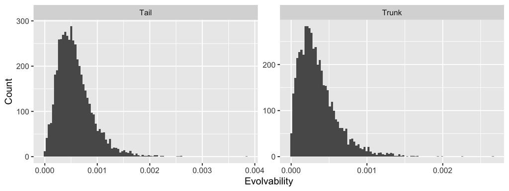

Evolvability as a percentage

|  | Trunk | Tail |
| --- | --- | --- |
| **lower.hdi** | 0.00002661 | 0.0003003 |
| **median** | 0.02977 | 0.05162 |
| **mode** | 0.02108 | 0.04385 |
| **upper.hdi** | 0.08472 | 0.1194 |
| **pr.lt.hdi** | 0 | 0.0002 |
| **pr.gt.hdi** | 0.0498 | 0.0496 |
| **5pc.exceeds** | 0.0846 | 0.1192 |

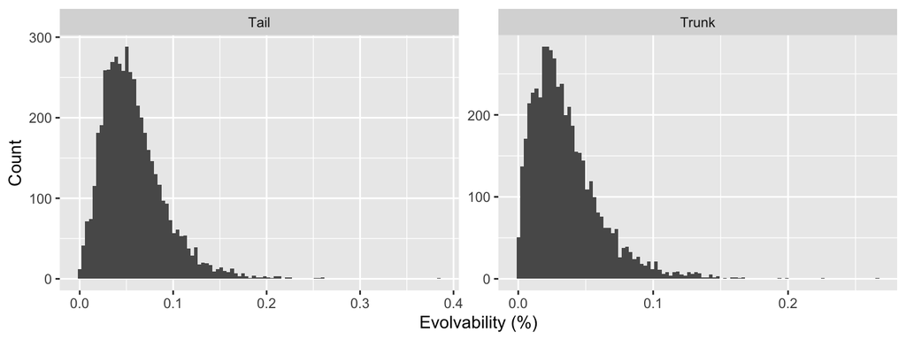

## Tail / Trunk Evolvability

| lower.hdi | median | mode | upper.hdi | pr.lt.hdi | pr.gt.hdi | 5pc.exceeds |
| --- | --- | --- | --- | --- | --- | --- |
| 0.2325 | 1.722 | 1.793 | 20.55 | 1.024 | 1.026 | 11.99 |

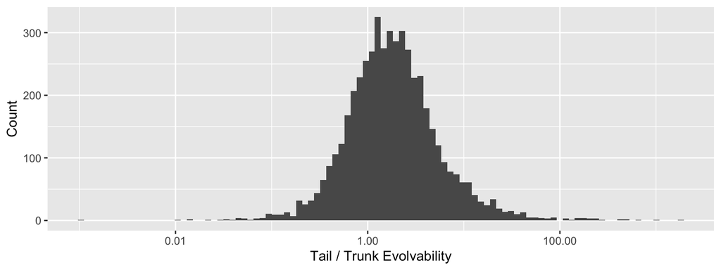

## Evolvability (from G matrix) Approach 1

This is for a random set of selection gradients.  
Multiply eB by 100 to get in units of percent.

| name | lower.hdi | median | mode | upper.hdi | pr.lt.hdi | pr.gt.hdi | 5pc.exceeds |
| --- | --- | --- | --- | --- | --- | --- | --- |
| eB | 0.000023 | 0.000245 | 0.000206 | 0.000527 | 0.0016 | 0.0482 | 0.000523 |
| rB | 0.000044 | 0.000286 | 0.000238 | 0.00066 | 0.0068 | 0.043 | 0.000642 |
| cB | 0.000012 | 0.000131 | 0.000118 | 0.000281 | 0.003 | 0.0468 | 0.000277 |
| iB | 0.03577 | 0.4349 | 0.4432 | 0.8053 | 0.016 | 0.0338 | 0.7717 |
| aB | 0.1947 | 0.5651 | 0.5568 | 0.9642 | 0.0338 | 0.016 | 0.909 |

## Evolvability (from G matrix) Approach 2

This is for a specific set of selection gradients:  
Beta_index = 1 is $\beta = \begin{bmatrix} 0 \\ 1 \end{bmatrix}$ = strong selection for longer tails only  
Beta_index = 2 is $\beta = \begin{bmatrix} -(1/\sqrt2) \\ -(1/\sqrt2) \end{bmatrix}$ = strong selection for shorter trunks and shorter tails  
Beta_index = 3 is $\beta = \begin{bmatrix} (1/\sqrt2) \\ -(1/\sqrt2) \end{bmatrix}$ = strong selection for longer trunks and shorter tails  
Multiply ‘evolvability’ by 100 to get in units of percent.

| Beta_index | metric | lower.hdi | median | mode | upper.hdi | pr.lt.hdi | pr.gt.hdi | 5pc.exceeds |
| --- | --- | --- | --- | --- | --- | --- | --- | --- |
| 1 | evolvability | 0.000003 | 0.000516 | 0.000438 | 0.001194 | 0.0002 | 0.0496 | 0.001192 |
| 2 | evolvability | 0.000048 | 0.00045 | 0.000368 | 0.001066 | 0.003 | 0.0468 | 0.001054 |
| 3 | evolvability | 0.000049 | 0.00038 | 0.000335 | 0.000878 | 0.0028 | 0.047 | 0.000868 |
| 1 | respondability | 0.000033 | 0.000539 | 0.000448 | 0.001238 | 0.0026 | 0.0472 | 0.001227 |
| 2 | respondability | 0.000073 | 0.000494 | 0.000389 | 0.001158 | 0.0052 | 0.0446 | 0.001129 |
| 3 | respondability | 0.000061 | 0.000428 | 0.000356 | 0.000956 | 0.002 | 0.0478 | 0.00095 |
| 1 | conditional | 0.000011 | 0.000439 | 0.000347 | 0.00107 | 0.002 | 0.0478 | 0.001064 |
| 2 | conditional | 0.000001 | 0.000337 | 0.000267 | 0.000898 | 0.0002 | 0.0496 | 0.000898 |
| 3 | conditional | 0.000001 | 0.000285 | 0.000217 | 0.00073 | 0.0004 | 0.0494 | 0.000729 |
| 1 | autonomy (cB/eB) | 0.5215 | 0.9291 | 0.9646 | 1 | 0.0498 | 0 | 0.9993 |
| 2 | autonomy (cB/eB) | 0.2189 | 0.8517 | 0.9259 | 1 | 0.0498 | 0 | 0.9986 |
| 3 | autonomy (cB/eB) | 0.2189 | 0.8517 | 0.9259 | 1 | 0.0498 | 0 | 0.9986 |
| 1 | integration | 0 | 0.07092 | 0.03544 | 0.4785 | 0 | 0.0498 | 0.4775 |
| 2 | integration | 0 | 0.1483 | 0.07411 | 0.7811 | 0 | 0.0498 | 0.781 |
| 3 | integration | 0 | 0.1483 | 0.07411 | 0.7811 | 0 | 0.0498 | 0.781 |

## Response to selection (%) from covariance. Approach 3

| param | lower.hdi | median | mode | upper.hdi | pr.lt.hdi | pr.gt.hdi | 5pc.exceeds |
| --- | --- | --- | --- | --- | --- | --- | --- |
| NA | -0.4171 | 0.04542 | 0.04029 | 0.6691 | 0.02208 | 0.02792 | 0.5249 |